# Numpy and Plotting

NumPy is a Python package that provides:

- a multi-dimensional *array* and whole-array operations
- fast matrix and vector operations
- a library of mathematical functions

To use NumPy in your code, you first need to import it:

```python
import numpy as np
```

After this `import ... as` statement, you can use all NumPy functions by prefixing them with `np.`

## NumPy arrays

NumPy’s main object is the homogeneous multidimensional array. It is a table of elements (usually numbers), all of the same type, indexed by a tuple of positive integers.

NumPy arrays (also called *ndarray*) are [constructed](https://docs.scipy.org/doc/numpy/user/basics.creation.html) with function `np.array`::

```python
a = np.array([1, 2, 3, 4, 5])
```

They behave behave a lot like Python lists:

```python
# get items using the [] operator
a[0]
```

```
1
```

```python
# get a slice using [:]
a[0:3]
```

```
array([1, 2, 3])
```

Note that again, a slice of a *ndarray* is again a *ndarray*.

```python
# set an item using [] =
a[4] = 0
```

```python
print(a)
```

```
[1 2 3 4 0]
```

Adding elements to an *ndarray* does not work as for *lists*

```python
a.append(4)
```

```
---------------------------------------------------------------------------
AttributeError                            Traceback (most recent call last)
<ipython-input-8-a39724ffcd65> in <module>()
----> 1 a.append(4)

AttributeError: 'numpy.ndarray' object has no attribute 'append'
```

Note that *ndarray*'s are **homogeneous** -- you cannot mix e.g. numbers and strings, and neither integers and floats:

```python
a[4] = 'five'
```

```
---------------------------------------------------------------------------
ValueError                                Traceback (most recent call last)
<ipython-input-9-77151a64b80d> in <module>()
----> 1 a[4] = 'five'

ValueError: invalid literal for int() with base 10: 'five'
```

```python
# here, the `5.5` is automatically converted to integer
a[4] = 5.5
```

```python
a
```

```
array([1, 2, 3, 4, 5])
```

### Setting the type of array items

Arrays are homogeneous (all elements must have the same type) and the [type](https://docs.scipy.org/doc/numpy/user/basics.types.html) is set at array creation time:

```python
a = np.array([1, 2, 3, 4, 5], dtype=np.float64)

a[4] = 5.5

# show a
print(a)
```

```
[1.  2.  3.  4.  5.5]
```

### Shortcuts for creating special arrays

Functions are available to create special arrays and matrices (see [here](https://docs.scipy.org/doc/numpy/reference/generated/numpy.eye.html#numpy.eye) for a complete reference):

- [`np.zeros(n)`](https://docs.scipy.org/doc/numpy/reference/generated/numpy.zeros.html#numpy.diag) return a 1D array of zeros with `n` elements;
- [`np.ones(n)`](https://docs.scipy.org/doc/numpy/reference/generated/numpy.zeros.html#numpy.diag) return a 1D array of 1's with `n` elements;
- [`np.random.rand(n)`](https://docs.scipy.org/doc/numpy/reference/generated/numpy.zeros.html#numpy.diag) return a 1D array of `n` random values, sampled from a uniform distribution over the real interval `[0, 1)`.
- [`np.random.randn(n)`](https://docs.scipy.org/doc/numpy/reference/generated/numpy.zeros.html#numpy.diag) return a 1D array of `n` random values, sampled from a univariate “normal” (Gaussian) distribution of mean 0 and variance 1.

The `np.arange()` function can be used to generate an *ndarray* containing equally-spaced points from an interval on the real line:

```python
# points in the interval [0,4) spaces 0.1 apart
x = np.arange(0, 4, 0.1)
```

```python
x
```

```
array([0. , 0.1, 0.2, 0.3, 0.4, 0.5, 0.6, 0.7, 0.8, 0.9, 1. , 1.1, 1.2,
       1.3, 1.4, 1.5, 1.6, 1.7, 1.8, 1.9, 2. , 2.1, 2.2, 2.3, 2.4, 2.5,
       2.6, 2.7, 2.8, 2.9, 3. , 3.1, 3.2, 3.3, 3.4, 3.5, 3.6, 3.7, 3.8,
       3.9])
```

We can easily create an array with constant value:

```python
y1 = np.ones(len(x))
```

```python
y1
```

```
array([1., 1., 1., 1., 1., 1., 1., 1., 1., 1., 1., 1., 1., 1., 1., 1., 1.,
       1., 1., 1., 1., 1., 1., 1., 1., 1., 1., 1., 1., 1., 1., 1., 1., 1.,
       1., 1., 1., 1., 1., 1.])
```

A line plot of `y1` over `x` will just show a flat horizontal line:

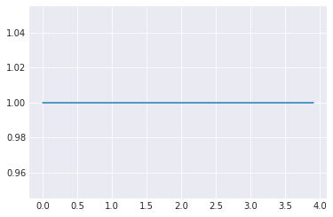

```python
plt.plot(x, y1)
```

The `np.linspace()` function works just like `np.arange()` but its third parameter is the *number of subdivisions of the interval* (as opposed to the difference of two consecutive points):

```python
y2 = np.linspace(0.5, 3, len(x))
```

```python
y2
```

```
array([0.5       , 0.56410256, 0.62820513, 0.69230769, 0.75641026,
       0.82051282, 0.88461538, 0.94871795, 1.01282051, 1.07692308,
       1.14102564, 1.20512821, 1.26923077, 1.33333333, 1.3974359 ,
       1.46153846, 1.52564103, 1.58974359, 1.65384615, 1.71794872,
       1.78205128, 1.84615385, 1.91025641, 1.97435897, 2.03846154,
       2.1025641 , 2.16666667, 2.23076923, 2.29487179, 2.35897436,
       2.42307692, 2.48717949, 2.55128205, 2.61538462, 2.67948718,
       2.74358974, 2.80769231, 2.87179487, 2.93589744, 3.        ])
```

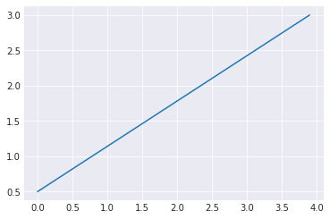

```python
plt.plot(x, y2)
```

Plotting different series of data in the same figure requires a bit more work:

1. First use the [`plt.subplots`](http://matplotlib.org/api/pyplot_api.html#matplotlib.pyplot.subplots) function to create *figure* and an *axes* object
2. An [*axes* object](http://matplotlib.org/api/axes_api.html#matplotlib.axes.Axes) is a "frame" for a single plot -- use methods [`.plot()`](http://matplotlib.org/api/_as_gen/matplotlib.axes.Axes.plot.html#matplotlib.axes.Axes.plot) to lay a graph onto the canvas. Each invocation of [`.plot()`](http://matplotlib.org/api/_as_gen/matplotlib.axes.Axes.plot.html#matplotlib.axes.Axes.plot) *adds* a plot onto the canvas.
3. The [*figure* object](http://matplotlib.org/api/figure_api.html#matplotlib.figure.Figure) contains all the axes can be used for saving the final output with [`.savefig()`](http://matplotlib.org/api/figure_api.html#matplotlib.figure.Figure.savefig)

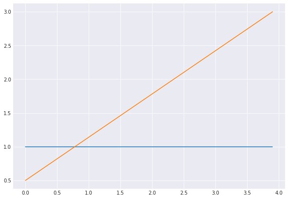

```python
fig, ax = plt.subplots(1, 1, figsize=[10, 7])

ax.plot(x, y1)
ax.plot(x, y2)

fig.savefig('lineplot.png')
```

### Exercise 4.A

Write a function `plotfn(xs, f)` that takes two arguments: a list of numbers `xs` and a mathematical function `f` (one single numerical argument, returns a number) and plots the graph of `f` on the domain `xs`.

#### Bonus points

Change the `plotfn()` function so to take an additional argument (a file name) and save the figure into that file.

#### More bonus points

Change the `plotfn()` function so to take a list of mathematical functions `fs` and plot all of them.

## Whole-array operations

NumPy arrays implement operators `+`, `-`, `*`, `/` as *element-wise operations*.

For instance, the array sum `a+b` is the array whose `i`-th element is `a[i]+b[i]`:

```python
a = np.array([1, 2, 3])
b = np.array([0.1, 0.2, 0.3])
c = a + b
```

```python
c
```

```
array([1.1, 2.2, 3.3])
```

Operations involving an array and a scalar value promote the scalar to a constant array having the same *shape*:

```python
y_a = y2 + 1.0
y_b = y2 - 1.0
```

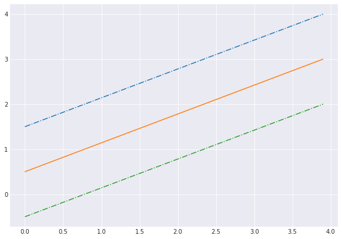

```python
fig, ax = plt.subplots(1, 1, figsize=[10, 7])

ax.plot(x, y_a, linestyle='-.')
ax.plot(x, y2)
ax.plot(x, y_b, linestyle='-.')
```

### Exercise 4.B

Plot the graph of function $f(x) = 1/x$

## Matrices and higher-dimensional arrays

NumPy allows creation and manipulation of multi-dimensional arrays, the prime example being 2D matrices.

The simplest way to initialize a matrix is to pass `np.array` a list of the matrix rows:

```python
m = np.array([[0, 1], [-1, 0]])
```

```python
m
```

```
array([[ 0,  1],
       [-1,  0]])
```

The *shape* of a multi-dimensional array is the number of elements along each dimension:

```python
m.shape
```

```
(2, 2)
```

For a 1-dimensional array, the shape is a list comprising a single number:

```python
x.shape
```

```
(40,)
```

*Differently from native Python lists,* indexing of multi-dimensional arrays is done with the syntax `m[i,j]` instead of `m[i][j]`:

```python
m[1,1] = 7
```

```python
m
```

```
array([[ 0,  1],
       [-1,  7]])
```

You can take the *transpose* of a matrix by using method `.T` (note: has to be *capital* T):

```python
m.T
```

```
array([[ 0, -1],
       [ 1,  7]])
```

Functions are available to create special matrices (see [here](https://docs.scipy.org/doc/numpy/reference/generated/numpy.eye.html#numpy.eye) for a complete reference):

- [`np.diag(a)`](https://docs.scipy.org/doc/numpy/reference/generated/numpy.diag.html#numpy.diag) return a square matrix having entries of array `a` along the diagonal. (Note that the length of `a` determines the dimension of the matrix.)
- [`np.eye(N,M)`](https://docs.scipy.org/doc/numpy/reference/generated/numpy.eye.html#numpy.eye) return the "identity" matrix of dimension $N \times M$

Of course, data can be read from disk to create multi-dimensional arrays.

Loading images is a typical way to create 2D arrays. The Python module `matplotlib.image` provides functions to read images into NumPy arrays:

```python
import matplotlib.image as mi

img1 = mi.imread('exercises/butterfly.png')
```

Function `plt.imshow()` and methods `ax.imshow()` allow displaying an array on a plotting surface. (Of course this can be combined with other plot types!)

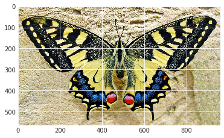

```python
plt.imshow(img1)
```

### Exercise 4.C

What is the exact size of the butterfly picture?

What are the dimensions of the `img1` array?

# Mathematical functions

NumPy provides a [vast choice of mathematical functions](https://docs.scipy.org/doc/numpy/reference/ufuncs.html#available-ufuncs) that *operate element-wise on arrays:* among them `np.sin`, `np.cos`, `np.tan`, `np.log`, `np.log2`, `np.log10`, `np.exp`.

### Exercise 4.D

Plot the functions $sin(x)$ and $2 \cdot cos(x) - 1$ on the interval $[-\pi, +\pi]$.

### Exercise 4.E

Define a function `gaussian(a, c, u, d)` which returns a 1D array with the values of the Gaussian function $f(x) = a \cdot \mathrm{e}^{-x^2/c}$ over the real interval $[-u, +u]$, sampled at points spaced $d$ apart. You can plot it in a few instances to check.

## Matrix-Vector and Matrix-Matrix multiplication

Function [`np.dot`](https://docs.scipy.org/doc/numpy/reference/generated/numpy.dot.html) is used to compute:

1. the dot (inner) product of two vectors
2. the matrix-vector product
3. matrix-matrix product (but the alternate spelling `np.matmul` is preferred)

Starting Python 3.5, the `@` infix operator can be used in place of `np.dot` -- i.e., you can write `A @ B` instead of `np.dot(A, B)`.

```python
a = np.array([0, 1])
b = np.array([1, 0])
```

The dot product of vectors `a` and `b` is 0:

```python
np.dot(a, b) # or: a @ b
```

```
0
```

```python
np.dot(a, a) # or: a @ a
```

```
1
```

When `np.dot` is applied to a matrix and a vector, the usual matrix-vector product results:

```python
np.dot(m, a) # or: m @ a
```

```
array([1, 7])
```

```python
np.dot(m, b)
```

```
array([ 0, -1])
```

Finally, when `np.dot` is applied to two matrices, the regular matrix-matrix multiplication takes place:

```python
np.matmul(m, m) # or: m @ m
```

```
array([[-1,  7],
       [-7, 48]])
```

## Array slicing

The slicing syntax $n:m$ can be used in *every dimension* of a multi-dimensional array.

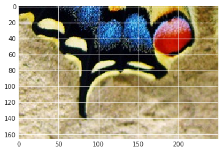

```python
img2 = img1[400:600, 250:500, 0:3]

plt.imshow(img2)
```

In particular, `:` can be used to mean "the whole range" in every dimension:

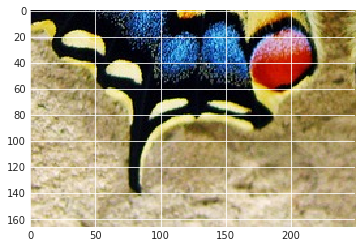

```python
img3 = img1[400:600, 250:500, :] # entire 3rd dim

plt.imshow(img3)
```

If a scalar number is used instead of a range, the resulting array will lack that dimension.

```python
img_r = img1[:, :, 0] # red channel

print(img_r.shape)
```

```
(567, 960)
```

Assignment to array slices is possible:

```python
# paint a patch uniform gray
img3[:,:,:] = 128
```

**Note:** Since sliced arrays are *views* on the original data, this modifies the starting object!

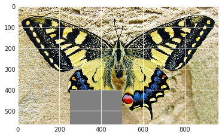

```python
plt.imshow(img1)
```

You should use the `.copy()` method of arrays explicitly if you want to take a slice that can be modified without affecting the original object.

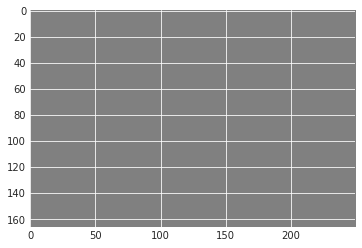

```python
img4 = img3.copy()

img4[:,:,:] = 255  # white

plt.imshow(img3) # still gray
```

### Exercise 4.F

To convert an image from RGB to gray scale, the following approximate procedure can be applied:

1. Convert each channel value of each pixel to an intensity value in the (real) range $[0, 1]$
2. Transform each intensity value $c$ according to the formula $c \mapsto ((c + 0.055) / 1.055)^{2.4}$
3. The gray intensity $y$ is defined by the formula: $y = 0.2126\cdot r + 0.7152\cdot g + 0.0722 \cdot b$.

Make a gray-scale version of the `butterfly.png` image, and compare it with `gray-butterfly.png`: are there any differences?

(For more information, see the [Wikipedia page "Grayscale"](https://en.wikipedia.org/wiki/Grayscale#Converting_color_to_grayscale))

```python
# insert code here and evaluate cell
```

## Removing and adding dimensions

Many mathematical functions of NumPy allow an additional `axis=...` parameter to specify on what array dimensions the function should operate; the result is again an array, where the indicated axes have been reduced by applying the function.

```python
# compute mean of each column
m1 = np.mean(img_r, axis=0)

print(m1.shape)
```

```
(960,)
```

```python
# compute mean of each row
m2 = np.mean(img_r, axis=1)

print(m2.shape)
```

```
(567,)
```

```python
# compute mean of whole array
m0 = np.mean(img_r, axis=(0,1))

print(m0)
```

```
10.377103
```

Conversely, one add an axis to an array using the [`np.expand_dims()`](https://docs.scipy.org/doc/numpy-1.15.0/reference/generated/numpy.expand_dims.html) function:

```python
x = np.array([1, 2, 3])  # 1D array
```

```python
y = np.expand_dims(x, 0)  # row (1xN) vector
print(y, y.shape)
```

```
[[1 2 3]] (1, 3)
```

```python
z = np.expand_dims(x, 1)  # column (Nx1) vector
print(z, z.shape)
```

```
[[1]
 [2]
 [3]] (3, 1)
```

For the full story, read the [Array indexing](https://docs.scipy.org/doc/numpy-1.15.0/user/basics.indexing.html#module-numpy.doc.indexing) page in the Numpy documentation, and the documentation of the [`np.reshape()`](https://docs.scipy.org/doc/numpy-1.15.0/reference/generated/numpy.reshape.html#numpy.reshape) function.

## Saving and loading in other formats

NumPy provides functions [`array = np.loadtxt(filename, dtype)`](https://docs.scipy.org/doc/numpy/reference/generated/numpy.loadtxt.html#numpy.loadtxt) and [`np.savetxt(filename, array)`](https://docs.scipy.org/doc/numpy/reference/generated/numpy.savetxt.html) that should be used to do *efficient* I/O of large arrays.

SciPy additionally provides functions [`scipy.io.loadmat()`](https://docs.scipy.org/doc/scipy/reference/generated/scipy.io.loadmat.html) and [`scipy.io.loadmat()`](https://docs.scipy.org/doc/scipy/reference/generated/scipy.io.savemat.html) to load/save matrices in MATLAB `.mat` format.

## Further reading

Nicolas Rougier has written excellent tutorials on the use of Matplotlib and NumPy:

- [Matplotlib tutorial](https://www.labri.fr/perso/nrougier/teaching/matplotlib/)
- [NumPy tutorial](http://www.labri.fr/perso/nrougier/teaching/numpy/numpy.html)

The Seaborn library comes with a good tutorial written by its author (note that -since Seaborn is an add-on to Matplotlib- some knowledge of Matplotlib is assumed):

- [Seaborn tutorial](http://seaborn.pydata.org/tutorial.html)

The [SciPy lecture notes](https://www.scipy-lectures.org/index.html) provide a good comprehensive introduction to various libraries in the Python numeric ecosystem.